# Assignment 4: Interpretation and Bias Considerations in ML

Juan D. Gelvez

## Setup

```r
library(caret)
library(randomForest)
library(partykit)
library(pdp)
library(iml)
```

## Data

Here we use data from the UCI Machine Learning repository on drug consumption. The data contains records for 1885 respondents with personality measurements (e.g. Big-5), level of education, age, gender, country of residence and ethnicity as features. In addition, information on the usage of 18 drugs is included.

Source: https://archive.ics.uci.edu/ml/datasets/Drug+consumption+%28quantified%29

```r
library(mlforsocialscience)
data(drugs)
```

#### 1) Predicting drug usage

**a) Prepare an outcome variable. For this you can choose from the variables on drug consumption and pick one drug (or a combination of drugs) as the prediction objective. The resulting variable should be of class `factor`, but it can have more than two categories if needed.**

```r
str(drugs) # structure of dataset drugs
```

```
## 'data.frame':    1885 obs. of  32 variables:
##  $ ID               : int  1 2 3 4 5 6 7 8 9 10 ...
##  $ Age              : Factor w/ 6 levels "-0.95197","-0.07854",..: 3 2 3 1 3 6 4 3 3 5 ...
##  $ Gender           : Factor w/ 2 levels "-0.48246","0.48246": 2 1 1 2 2 2 1 1 2 1 ...
##  $ Education        : Factor w/ 9 levels "-2.43591","-1.7379",..: 6 9 6 8 9 4 8 2 6 8 ...
##  $ Country          : Factor w/ 7 levels "-0.57009","-0.46841",..: 7 7 7 7 7 6 1 7 6 7 ...
##  $ Ethnicity        : Factor w/ 7 levels "-1.10702","-0.50212",..: 6 3 3 3 3 3 3 3 3 3 ...
##  $ Neuroticism      : num  0.313 -0.678 -0.467 -0.149 0.735 ...
##  $ Extraversion     : num  -0.575 1.939 0.805 -0.806 -1.633 ...
##  $ Openness         : num  -0.5833 1.4353 -0.8473 -0.0193 -0.4517 ...
##  $ Agreeableness    : num  -0.917 0.761 -1.621 0.59 -0.302 ...
##  $ Conscientiousness: num  -0.00665 -0.14277 -1.0145 0.58489 1.30612 ...
##  $ Impulsive        : num  -0.217 -0.711 -1.38 -1.38 -0.217 ...
##  $ SS               : num  -1.181 -0.216 0.401 -1.181 -0.216 ...
##  $ Alcohol          : chr  "CL5" "CL5" "CL6" "CL4" ...
```

[output cut: 18 more lines]

```r
head(drugs)
```

|  | ID | Age | Gender | Education | Country | Ethnicity | Neuroticism | Extraversion | Openness | Agreeableness | Conscientiousness | Impulsive | SS | Alcohol | Amphet | Amyl | Benzos | Caff | Cannabis | Choc | Coke | Crack | Ecstasy | Heroin | Ketamine | Legalh | LSD | Meth | Mushrooms | … |
| --- | --- | --- | --- | --- | --- | --- | --- | --- | --- | --- | --- | --- | --- | --- | --- | --- | --- | --- | --- | --- | --- | --- | --- | --- | --- | --- | --- | --- | --- | --- |
| 1 | 1 | 0.49788 | 0.48246 | -0.05921 | 0.96082 | 0.126 | 0.31287 | -0.57545 | -0.58331 | -0.91699 | -0.00665 | -0.21712 | -1.18084 | CL5 | CL2 | CL0 | CL2 | CL6 | CL0 | CL5 | CL0 | CL0 | CL0 | CL0 | CL0 | CL0 | CL0 | CL0 | CL0 | … |
| 2 | 2 | -0.07854 | -0.48246 | 1.98437 | 0.96082 | -0.31685 | -0.67825 | 1.93886 | 1.43533 | 0.76096 | -0.14277 | -0.71126 | -0.21575 | CL5 | CL2 | CL2 | CL0 | CL6 | CL4 | CL6 | CL3 | CL0 | CL4 | CL0 | CL2 | CL0 | CL2 | CL3 | CL0 | … |
| 3 | 3 | 0.49788 | -0.48246 | -0.05921 | 0.96082 | -0.31685 | -0.46725 | 0.80523 | -0.84732 | -1.62090 | -1.01450 | -1.37983 | 0.40148 | CL6 | CL0 | CL0 | CL0 | CL6 | CL3 | CL4 | CL0 | CL0 | CL0 | CL0 | CL0 | CL0 | CL0 | CL0 | CL1 | … |
| 4 | 4 | -0.95197 | 0.48246 | 1.16365 | 0.96082 | -0.31685 | -0.14882 | -0.80615 | -0.01928 | 0.59042 | 0.58489 | -1.37983 | -1.18084 | CL4 | CL0 | CL0 | CL3 | CL5 | CL2 | CL4 | CL2 | CL0 | CL0 | CL0 | CL2 | CL0 | CL0 | CL0 | CL0 | … |
| 5 | 5 | 0.49788 | 0.48246 | 1.98437 | 0.96082 | -0.31685 | 0.73545 | -1.63340 | -0.45174 | -0.30172 | 1.30612 | -0.21712 | -0.21575 | CL4 | CL1 | CL1 | CL0 | CL6 | CL3 | CL6 | CL0 | CL0 | CL1 | CL0 | CL0 | CL1 | CL0 | CL0 | CL2 | … |
| 6 | 6 | 2.59171 | 0.48246 | -1.22751 | 0.24923 | -0.31685 | -0.67825 | -0.30033 | -1.55521 | 2.03972 | 1.63088 | -1.37983 | -1.54858 | CL2 | CL0 | CL0 | CL0 | CL6 | CL0 | CL4 | CL0 | CL0 | CL0 | CL0 | CL0 | CL0 | CL0 | CL0 | CL0 | … |

```r
#creating cannabis used
drugs$Cannabis_Used <- factor(ifelse(drugs$Cannabis == "CL0", "Never Used", "Used")) #creating a binary indicator
table(drugs$Cannabis_Used)
```

```
##
## Never Used       Used
##        413       1472
```

```r
drugs$Cannabis_Level <- factor(drugs$Cannabis,
                               levels = c("CL0", "CL1", "CL2", "CL3", "CL4", "CL5", "CL6"),
                               ordered = TRUE) # Ensure the Cannabis variable is a factor with ordered levels
str(drugs$Cannabis_Level) #it's class `factor`
```

```
##  Ord.factor w/ 7 levels "CL0"<"CL1"<"CL2"<..: 1 5 4 3 4 1 2 1 1 2 ...
```

**b) Next split the data into a training and a test part.**

```r
set.seed(9574)

inTrain <- createDataPartition(drugs$Cannabis_Used,
                               p = 0.8,
                               list = FALSE,
                               times = 1)

# Creating the training dataset
drugs_train <- drugs[inTrain,]

# Creating the test dataset
drugs_test <- drugs[-inTrain,]
```

**c) Specify the evaluation method for the `train()` function of `caret` with 10-fold cross-validation.**

```r
ctrl <- trainControl(method = "cv", number = 10)
model <- train(Cannabis_Used ~ ., data = drugs_train, trControl = ctrl)
model
```

```
## Random Forest
##
## 1509 samples
##   33 predictor
##    2 classes: 'Never Used', 'Used'
##
## No pre-processing
## Resampling: Cross-Validated (10 fold)
## Summary of sample sizes: 1358, 1358, 1359, 1358, 1358, 1358, ...
## Resampling results across tuning parameters:
##
##   mtry  Accuracy   Kappa
##     2   0.9947062  0.9842805
##    76   1.0000000  1.0000000
##   151   1.0000000  1.0000000
##
## Accuracy was used to select the optimal model using the largest value.
## The final value used for the model was mtry = 76.
```

**d) Specify a grid object for tuning a random forest model.**

```r
tuneGrid <- expand.grid(mtry = c(2, sqrt(ncol(drugs_train)), ncol(drugs_train)/3))

rf_model <- train(Cannabis_Used ~ ., data = drugs_train,
                 method = "rf", # Random Forest
                 tuneGrid = tuneGrid,
                 trControl = trainControl(method = "cv", number = 10)) # 10-fold CV
```

**e) Use `train()` from `caret` in order to grow the forest. Do not use any of the other drugs as predictors in this model. Determine the best model based on the tuning results.**

```r
predictorVars <- c("Age", "Gender", "Education", "Country", "Ethnicity",
                   "Neuroticism", "Extraversion", "Openness", "Agreeableness",
                   "Conscientiousness", "Impulsive", "SS", "Cannabis_Used")
new_db <- drugs_train[, predictorVars]



trainCtrl <- trainControl(method = "cv", number = 15)
tuneGridRF <- expand.grid(mtry = c(2, sqrt(ncol(new_db)-1), (ncol(new_db)-1)/3))
rfModel <- train(Cannabis_Used ~ ., data = new_db,
                 method = "rf", # specifies random forest
                 trControl = trainCtrl,
                 tuneGrid = tuneGridRF)
```

#### 2) Interpreting the model

**a) Find and create a plot of the variable importances. What are you interpretations of this?**

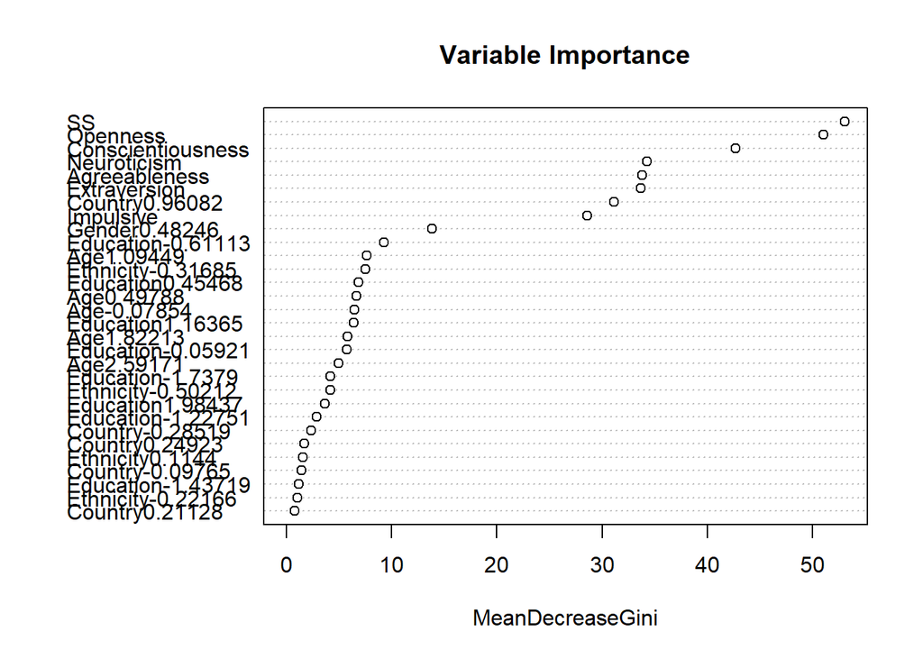

```r
varImpPlot(rfModel$finalModel, main="Variable Importance")
```

In the previous graph each dot represents a predictor variable, and the x-axis indicates the mean decrease in Gini impurity when that variable is used for splitting in the model. Variable Openness and SS seem to have the largest Mean Decrease Gini. These suggest that both are highly predictive of cannabis usage among the variables considered.

**b) Create some partial dependence plots. What are your interpretations of these plots?**

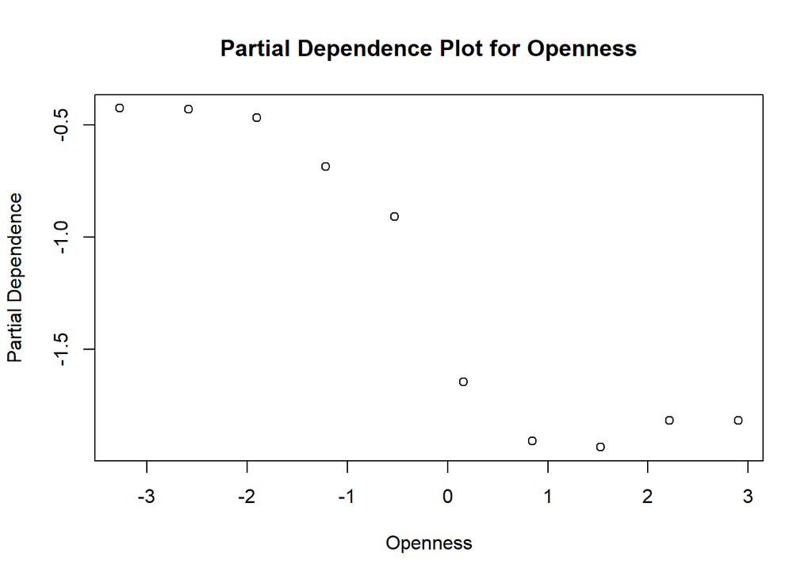

```r
# partial dependence plot for 'Openness' and 'SS'
pdp_openness <- partial(rfModel, pred.var = "Openness", train = new_db, grid.resolution = 10)
plot(pdp_openness, main = "Partial Dependence Plot for Openness", xlab = "Openness", ylab = "Partial Dependence")
```

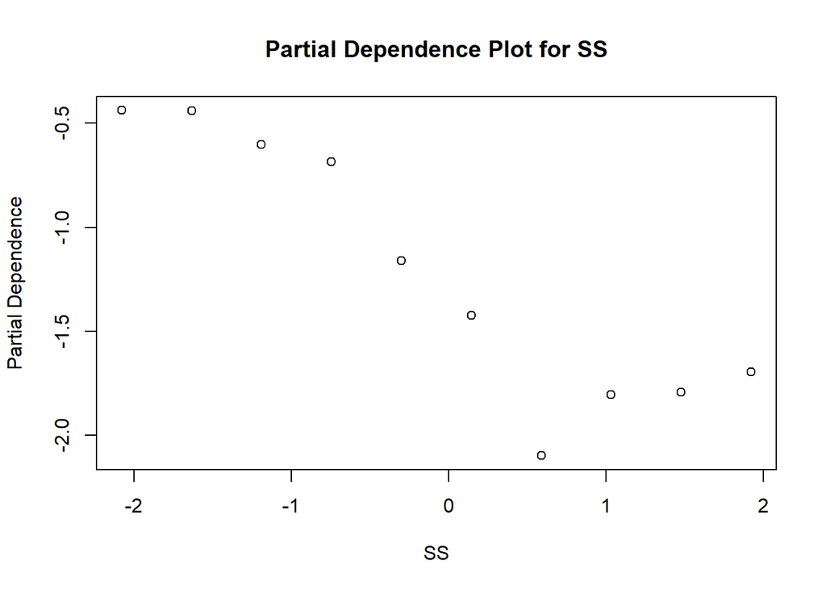

```r
pdp_ss <- partial(rfModel, pred.var = "SS", train = new_db, grid.resolution = 10)
plot(pdp_ss, main = "Partial Dependence Plot for SS", xlab = "SS", ylab = "Partial Dependence")
```

The partial dependence plot for Openness and SS show the relationship between the predictor variables and the predicted outcome after averaging out the effects of the other variables in the model. For both graphs, the axis represents the range of values for the ‘Openness’ and SS personality trait, likely standardized (as indicated by the negative and positive values around 0).